# Slides-BLTPPrecautionarySavings-ToramanSY slides

Precautionary Savings, Illiquid Assets, and the Aggregate Consequences of Shocks to Household Income Risk

Christian Bayer, Ralph Luetticke, Liam Pham-Dao and Volker Tjaden

November 3, 2020

Slides by: Sinem Yagmur Toraman

# Outline

- Summary
- Overview
- Estimation of risk over time
- Responses of shocks to income risk
- The model
- Results
- Conclusion

## Summary

- Macroeconomic implications of the large income uncertainty faced by the households over the business cycle with a dynamic stochastic general equilibrium model
  - Incomplete markets
  - Liquid and illiquid assets
  - Nominal rigidity

### What differentiates the paper from the previous literature?

- The portfolio adjustment as a new channel through which uncertainty affects real activity
- The focus on idiosyncratic income risk
- Isolation of precautionary savings and portfolio channel of income uncertainty
- Introduction of two asset structure
- The investigation of distributional consequences of systematic monetary and fiscal policy with an emphasis on potfolios

## Overview

### Two Asset Structure

- Households can hold two types of assets for consumption smoothing:
  - Liquid (low return) nominal bonds
  - Illiquid (high-dividend-paying) physical capital

### Incomplete markets

- Sticky prices a la Rotemberg (1982)

### Two types of households

- Workers
- Entrepreneurs

## Estimation of income risk over time

### Income process

- The data is restricted to housholds between the age of 30-56 and the labor income of the household is given by:

$$ logy_{it} = f(o_{it}) + \tau_{it} + h_{it} + \mu_{i}$$$$ h_{it} = \sum_{s=c}^{t}\rho_{h}^{t-s}\varepsilon_{is}^{h}$$$$ \tau_{it} = \varepsilon_{it}^{\tau} + \rho_{\tau}\varepsilon_{it-1}^{\tau} $$$$ \varepsilon_{it}^{\tau} \thicksim \mathcal{N}(0,\sigma_{\tau}^{2}),$$

$$\varepsilon_{it}^{h} \thicksim \mathcal{N}(0,\sigma_{\varepsilon,t}^{2}),$$ $$\mu_{i}\thicksim \mathcal{N}(0,\sigma_{\mu}^{2})$$

where

- c: cohort by the quarter when the head of the household turns 30
- $f(o_{it})$: measures the observable characteristics $o_{it}$
- $ \tau_{it}$: MA(1) transitory shock
- $\mu_{i}$: fixed effect
- $h_{it}$: persistent component

### Risk process

- Transitory shocks and fixed effects are assumed to be homoscedastic
- Variance of the shocks $\varepsilon_{it}^{h}$ to the persistent component follows an AR(1) process:

$$\sigma_{\varepsilon,t}^{2} = \bar{\sigma_{\varepsilon,t}^{2}}exp(s_{t}+t\theta_{1}+t^{2}\theta_{2})$$$$s_{t+1} =\rho_{s}s_{t}+ \varepsilon_{t}^{s}$$$$ \varepsilon_{t}^{s} \thicksim \mathcal{N}\left(-\dfrac{\sigma_{s}^{2}}{2(1+\rho_{s})},\sigma_{s}^{2}\right)$$

## Responses to shocks to income risk

### Aggregate response

- As a result of an increase in income risk
  - aggregate output $\downarrow$
  - investment $\downarrow$
  - return premium of illiquid assets $\uparrow$
  - ratio of liquid to illiquid assets $\uparrow$

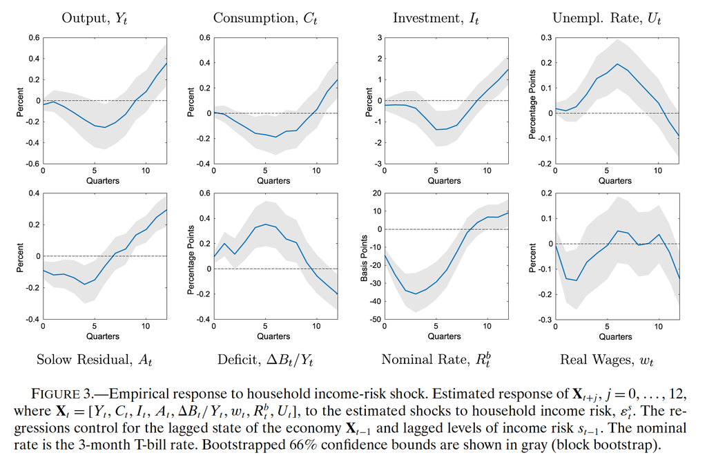

### Response by wealth group

- The analysis relies on the data collected for 1983-2013 from Survey of Consumer Finances (SCF) focusing on households with the following characteristics:
  - head of the household is at the age of 30-55
  - at least two adults
  - married
- Increase in liquidty intensifies as the household gets poorer

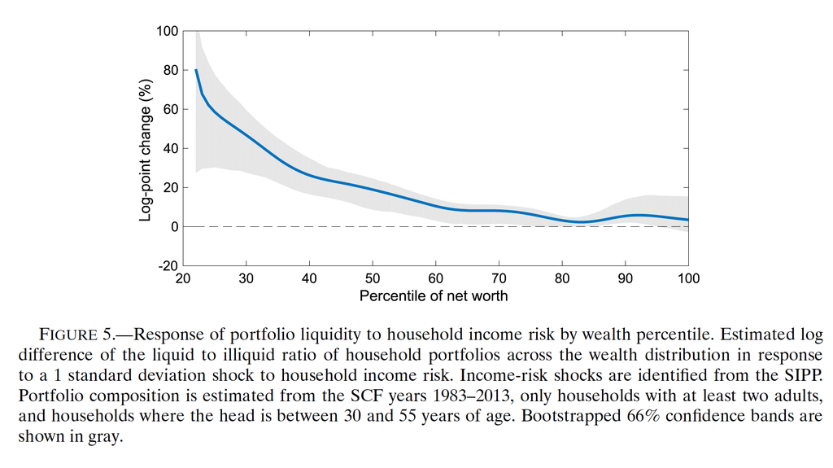

## The Model

### Quantitative Model

- It is a dynamic heterogenous households model with
  - incomplete markets
  - time variations in income risks and
  - sticky prices (a la Rotemberg (1982))

## Agents

### Households

- Unit mass of ex ante identical, infinitely lived households
- Time separable preferences described by Greenwood–Hercowitz–Huffman (GHH) preferences
- Derive felicity from consumption, $c_{it}$, and leisure
- Earn income from
  - supplying labor $n_{it}$
  - renting out capital $k_{it}$
  - interest on bonds $b_{it}$
- Holdings of capital is adjusted by incurring a felicity cost, $\chi_{it}$, which is i.i.d. from a logistic distribution
- Holdings of bonds are above $ \underline{B} $, and holdings of capital are nonnegative
- Nonparticipants of the capital market still get dividends and able to adjust bond holdings
- There is a wasted intermediation cost of $\bar{R}$

### Households (Cont.)

- Workers
  - Supply labor
  - Productivity evolves randomly given by

$$ \tilde{h_{it}} = \left\{ \begin{array}{ll} exp \left(\rho_{h}log \tilde{h_{it}}+ \varepsilon_{it}^{h}\right) & \text{with probability $1-\xi$} & \text{if $h_{it-1}\neq 0$}, \\ 1 & \text{with probability $\imath$} & \text{if $h_{it-1}=0$}, \\ 0 & \text{else} \end{array} \right. $$

where

$ h_{it} = \dfrac{\tilde{h_{it}}}{\int\tilde{h_{it}}di} $

- Variance of the shocks to productivity is given by the following set of equations:

$$\sigma_{h,t}^{2}={\bar{\sigma}}_{h}^{2}exps_{t}$$$$s_{t+1} =\rho_{s}s_{t} + \varepsilon_{t}^{s}$$$$ \varepsilon_{t}^{s} \thicksim \mathcal{N}\left(-\dfrac{\sigma_{s}^{2}}{2(1+\rho_{s})},\sigma_{s}^{2}\right)$$

### Households (Cont.)

- Entrepreneurs
  - Do not work, earn pure rents
- Households maximize the discounted sum of felicity:

$$ E_{0} = max _{{c_{it},n_{it},\Delta k_{it}}} \sum_{t=0}^{\infty} \beta^{t} u[cn-G(h_{it},n_{it})]-\mathbb{1}_{\Delta_{k_{it}\neq0}} \chi_{it} $$

subject to the budget constraint:

$$ c_{it}+b_{it}+q_{t}k_{it+1} =b_{it}\dfrac{R(b_{it},R_{t}^{b}}{\pi_t} +(q_{t}+r_{t})k_{it}+(1-\tau)(w_{t}h_{it}N_{t} + \mathbb{1}_{h_{it}=0} \Pi_{t}),$$$$k_{it}\geq 0,$$$$b_{it+1}\geq \underline{B}$$

where

- $\chi_{it}$: utility cost of adjustment
- $x_{it}= c_{it}-G(h_{it},n_{it})$

  where
  - G measures the disutility from work and
  - $c_{it} = \left(\int c_{ijt}^{\dfrac{\eta-1}{\eta}}dj\right)^\dfrac{\eta}{\eta-1}$

### Households (Cont.)

- Felicity function u exhibits CRRA with $\xi$>0 denoting the risk aversion parameter:

$$u(x_{it})=\dfrac{1}{1-\xi}x_{it}^{1-\xi}$$

and

- $b_{it}$: real bond holdings
- $\underline{B}$: exogenous borrowing constraint
- $k_it$: amount of illiquid asset
- $q_{t}$: price of illiquid asset
- $r_t$: dividend
- $\pi_{t}=\dfrac{P_t}{P_{t-1}}$: realized inflation
- $R$: nominal gross return on bonds
- $R_t^b$: Central Bank's interest rate

### There are 3 functions characterizing the household’s problem:

$V_{a}(b,k,h:\Theta,R^{b},s) = max_{k',b'_{a}}u[x(b,b'_{a},k,k',h)]+\beta EV(b'_{a},k',h',\Theta',R^{b'},s'),$

$V_{n}(b,k,h:\Theta,R^{b},s) = max_{k',b'_{n}}u[x(b,b'_{n},k,k',h)]+\beta EV(b'_{n},k',h',\Theta',R^{b'},s'),$

$EV(b',k',h:\Theta,R^{b},s) = E_{\xi',h',s'} {max[V_{a}(b',k',h';\Theta',R^{b'},s') - \xi', V_{n}(b',k',h';\Theta',R^{b'},s')]}$

### Intermediate-Goods Producers

- CRS production function

$$ Y_{t} = N_{t}^{\alpha}K_{T}^{1-\alpha}$$

- They maximize profit

$$MC_{t}Y_{t} -w_{t}N_{t} -(r_{t}\delta)K_{t} = MC_{t}N_{t}^{\alpha}K_{T}^{1-\alpha} - w_{t}N_{t}-(r_{t}+\delta)K_{t}$$

- Perfectly competitive markets

$$w_t = \alpha MC_{t}\left(K_{t}/N_{t}\right)^ {1-\alpha}, $$

$$r_{t}+\delta = (1-\alpha)MC_{t}(N_{t}/K_{t})^{\alpha}$$

### Final-Goods Producers

- Price adjustment costs à la Rotemberg (1982)
- Risk neutral managers compensated by a share in profits
- Not participating in the asset market
- With quadratic costs of adjustment they maximize

$$ E_{0} \sum_{t=0}^{\infty} \beta^{t} Y_{T} \left \lbrace \left(\dfrac{p_{jt}}{P_{t}}-MC_{t}\right)\left(\dfrac{p_{jt}}{P_{t}}\right )^{-\eta} - \dfrac{\eta}{2 \kappa} \left (log\dfrac{p_{jt}}{p_{jt-1}} \right)^{2} \right \rbrace $$

- Phillips curve is given by

$$log(\pi_{t})=\beta E_{t}\left [log\left(\pi_{t+1}\right)\dfrac{Y_{t+1}}{Y_{t}}\right]+ \kappa\left (MC_{t} - \dfrac{\eta-1}{\eta} \right)$$

### Government

- Monetary authority: Nominal interest rates on liquid assets are set according to

$$\dfrac{R_{t+1}^{b}}{\bar{R}^{b}} =\left( \dfrac{R_{t}^{b}}{\bar{R}^{b}}\right)^{2}\left(\dfrac{\pi_{t}}{\bar{\pi}}\right)^{(1-\rho R)\theta_{t}}$$

- Fiscal authority: Issuance of government bonds according to

$$ \dfrac{B_{t+1}}{\bar{B}}= \left( \dfrac{B_{t}R_{t}^{b}/ \pi_{t}}{\bar{B}\bar{R}^{b}/ \bar{\pi}}\right)^{\rho B} \left(\dfrac{\pi_{t}}{\bar{\pi}} \right)^{-\gamma \pi} \left( \dfrac{\mathcal{T}}{\bar{\mathcal{T}}} \right)^{-\gamma \mathcal{T}}$$

## Results

### Household portfolios and the individual response to income risk

- In partial equilibrium setting:
  - Consumption declines for all households
  - Increase in income risk makes households consume less and save more in liquid form by selling illiquid capital
  - Portfolio liquidity increases for all households

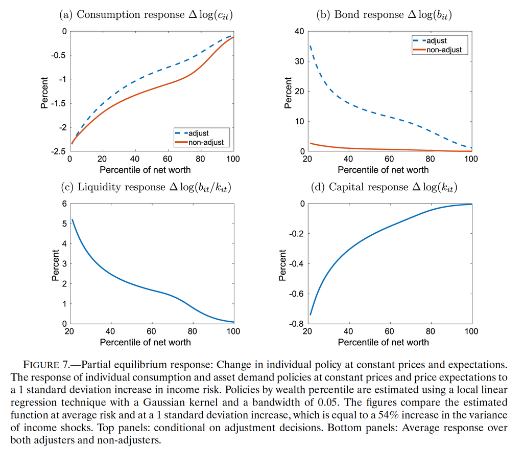

### Household portfolios and the individual response to income risk (Cont.)

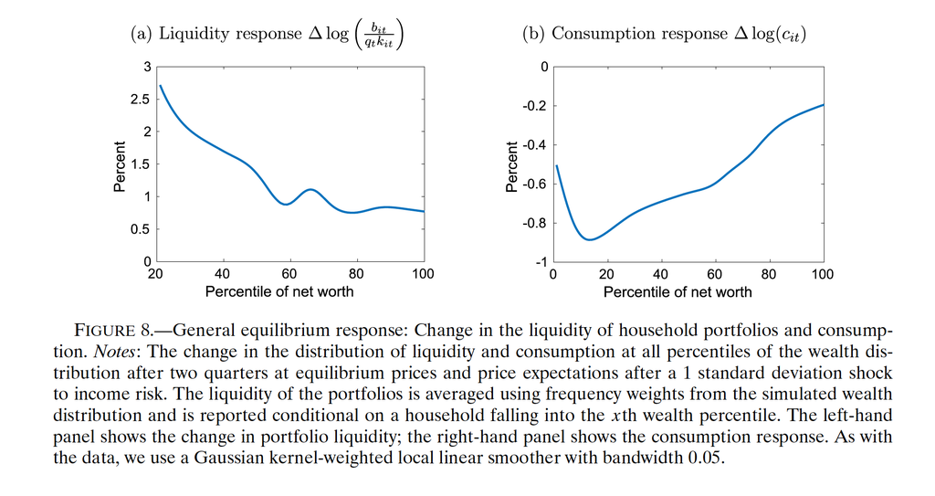

### Aggregate consequences of shocks to household income risk

- An increase in the variance of the income shock by a magnitude of 1 standard deviation:
  - Output drops by 0.2%, recovering only after 12 quarters
  - Drop in consumption is much larger, recovering only after 20 quarters
  - Investment experiences the sharpest decline, which is five times larger than that of output
  - Fluctuations in household income risk captures the 21 % of the fluctuations in the business cycle

### Stabilization policy

- In addition to the baseline calibration of fiscal and monetary policy, they consider two additional scenarios:
  - perfect stabilization through monetary policy
  - perfect stabilization through fiscal policy

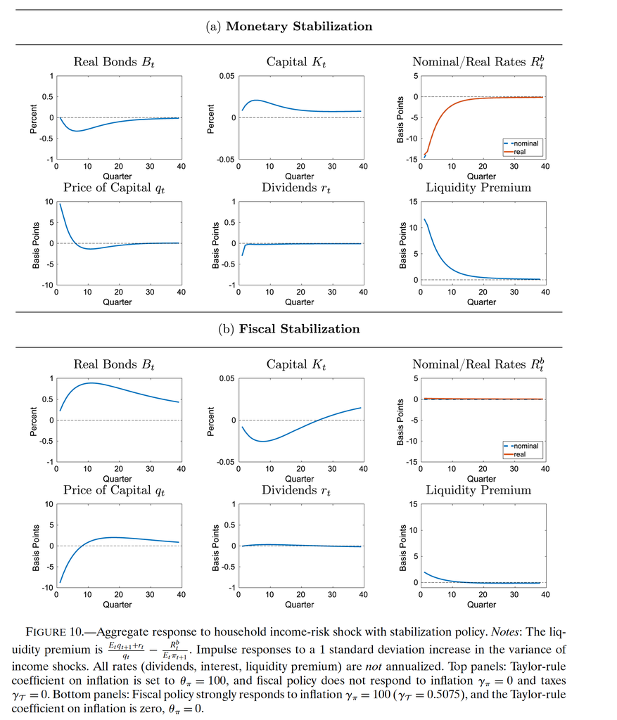

### Redistributive and welfare effects

An increase in the household income risk worth of 1 % standard deviation leads to a decrease in lifetime consumption of 27 basis points on average

- Welfare loss is bigger for households with fewer asset holdings

Distributional consequences differ between different stabilization policies:

- Fiscal policy benefits people with a higher amount of illiquid wealth
- Monetary policy benefits people with a very low levels of wealth, taking from the people with liquid portfolios
- For well insured and wealthy households, changes in equilibrium prices are of great importance. Thus, they suffer more from stabilizing monetary policy due to its impact on decreasing asset returns. In contrast, they are better off by a fiscal policy stabilization due to its impact on crowding out the investment and keeping the returns high.

## Conclusion

- An analysis on the impact of fluctuations in the riskiness of household income through the lens of precautionary savings
- They show that an increase in the income risk induces flight to liquidity as people prefer liquid assets over the illiquid assets for consumption smoothing puposes in the short-run
- They introduce the “portfolio rebalancing” channel to describe how uncertainty can induce a recession
- Findings are also helpful in understanding the severity of the Great Recession
  - 1 standard deviation increase in household income risk gives the following results:
    - Drop in aggregate activity by 0.2% and investment by 1% over the first year after the shock
    - At ZLB, when neither monetary nor fiscal policy are ineffective in stabilizing the economy, there is a loss of almost 2 %